# Risk Factor Analysis

## Outcome Variable

**Outcome Variable:** haz

## Predictor Variables

**Intervention Variable:** single

**Adjustment Set:**

- arm
- W_mage
- W_fage
- meducyrs
- feducyrs
- W_mhtcm
- W_mwtkg
- W_mbmi
- W_gagebrth
- W_birthwt
- W_birthlen
- vagbrth
- parity
- delta_W_mage
- delta_W_fage
- delta_meducyrs
- delta_feducyrs
- delta_W_mhtcm
- delta_W_mwtkg
- delta_W_mbmi
- delta_W_gagebrth
- delta_W_birthwt
- delta_W_birthlen
- delta_vagbrth
- delta_parity

## Stratifying Variables

The analysis was stratified on these variable(s):

- agecat
- studyid
- country

## Data Summary

| agecat | studyid | country | single | n_cell | n |
| --- | --- | --- | --- | --- | --- |
| 6 months | ki0047075b-MAL-ED | BANGLADESH | 0 | 241 | 241 |
| 6 months | ki0047075b-MAL-ED | BANGLADESH | 1 | 0 | 241 |
| 6 months | ki0047075b-MAL-ED | BRAZIL | 0 | 179 | 209 |
| 6 months | ki0047075b-MAL-ED | BRAZIL | 1 | 30 | 209 |
| 6 months | ki0047075b-MAL-ED | INDIA | 0 | 234 | 234 |
| 6 months | ki0047075b-MAL-ED | INDIA | 1 | 0 | 234 |
| 6 months | ki0047075b-MAL-ED | NEPAL | 0 | 236 | 236 |
| 6 months | ki0047075b-MAL-ED | NEPAL | 1 | 0 | 236 |
| 6 months | ki0047075b-MAL-ED | PERU | 0 | 240 | 273 |
| 6 months | ki0047075b-MAL-ED | PERU | 1 | 33 | 273 |
| 6 months | ki0047075b-MAL-ED | SOUTH AFRICA | 0 | 140 | 254 |
| 6 months | ki0047075b-MAL-ED | SOUTH AFRICA | 1 | 114 | 254 |
| 6 months | ki0047075b-MAL-ED | TANZANIA, UNITED REPUBLIC OF | 0 | 239 | 247 |
| 6 months | ki0047075b-MAL-ED | TANZANIA, UNITED REPUBLIC OF | 1 | 8 | 247 |
| 6 months | ki1066203-TanzaniaChild2 | TANZANIA, UNITED REPUBLIC OF | 0 | 1835 | 2013 |
| 6 months | ki1066203-TanzaniaChild2 | TANZANIA, UNITED REPUBLIC OF | 1 | 178 | 2013 |
| 6 months | ki1112895-Guatemala BSC | GUATEMALA | 0 | 248 | 277 |
| 6 months | ki1112895-Guatemala BSC | GUATEMALA | 1 | 29 | 277 |
| 6 months | ki1119695-PROBIT | BELARUS | 0 | 15118 | 15761 |
| 6 months | ki1119695-PROBIT | BELARUS | 1 | 643 | 15761 |
| 6 months | ki1126311-ZVITAMBO | ZIMBABWE | 0 | 7775 | 8265 |
| 6 months | ki1126311-ZVITAMBO | ZIMBABWE | 1 | 490 | 8265 |
| 6 months | ki1135781-COHORTS | GUATEMALA | 0 | 826 | 893 |
| 6 months | ki1135781-COHORTS | GUATEMALA | 1 | 67 | 893 |
| 6 months | ki1135781-COHORTS | INDIA | 0 | 4962 | 4971 |
| 6 months | ki1135781-COHORTS | INDIA | 1 | 9 | 4971 |
| 6 months | ki1135781-COHORTS | PHILIPPINES | 0 | 2608 | 2676 |
| 6 months | ki1135781-COHORTS | PHILIPPINES | 1 | 68 | 2676 |
| 24 months | ki0047075b-MAL-ED | BANGLADESH | 0 | 212 | 212 |
| 24 months | ki0047075b-MAL-ED | BANGLADESH | 1 | 0 | 212 |
| 24 months | ki0047075b-MAL-ED | BRAZIL | 0 | 148 | 169 |
| 24 months | ki0047075b-MAL-ED | BRAZIL | 1 | 21 | 169 |
| 24 months | ki0047075b-MAL-ED | INDIA | 0 | 225 | 225 |
| 24 months | ki0047075b-MAL-ED | INDIA | 1 | 0 | 225 |
| 24 months | ki0047075b-MAL-ED | NEPAL | 0 | 228 | 228 |
| 24 months | ki0047075b-MAL-ED | NEPAL | 1 | 0 | 228 |
| 24 months | ki0047075b-MAL-ED | PERU | 0 | 176 | 201 |
| 24 months | ki0047075b-MAL-ED | PERU | 1 | 25 | 201 |
| 24 months | ki0047075b-MAL-ED | SOUTH AFRICA | 0 | 131 | 238 |
| 24 months | ki0047075b-MAL-ED | SOUTH AFRICA | 1 | 107 | 238 |
| 24 months | ki0047075b-MAL-ED | TANZANIA, UNITED REPUBLIC OF | 0 | 208 | 214 |
| 24 months | ki0047075b-MAL-ED | TANZANIA, UNITED REPUBLIC OF | 1 | 6 | 214 |
| 24 months | ki1066203-TanzaniaChild2 | TANZANIA, UNITED REPUBLIC OF | 0 | 6 | 6 |
| 24 months | ki1066203-TanzaniaChild2 | TANZANIA, UNITED REPUBLIC OF | 1 | 0 | 6 |
| 24 months | ki1119695-PROBIT | BELARUS | 0 | 3890 | 4035 |
| 24 months | ki1119695-PROBIT | BELARUS | 1 | 145 | 4035 |
| 24 months | ki1126311-ZVITAMBO | ZIMBABWE | 0 | 413 | 456 |
| 24 months | ki1126311-ZVITAMBO | ZIMBABWE | 1 | 43 | 456 |
| 24 months | ki1135781-COHORTS | GUATEMALA | 0 | 926 | 1013 |
| 24 months | ki1135781-COHORTS | GUATEMALA | 1 | 87 | 1013 |
| 24 months | ki1135781-COHORTS | INDIA | 0 | 3747 | 3756 |
| 24 months | ki1135781-COHORTS | INDIA | 1 | 9 | 3756 |
| 24 months | ki1135781-COHORTS | PHILIPPINES | 0 | 2357 | 2416 |
| 24 months | ki1135781-COHORTS | PHILIPPINES | 1 | 59 | 2416 |

The following strata were considered:

- agecat: 24 months, studyid: ki0047075b-MAL-ED, country: BANGLADESH
- agecat: 24 months, studyid: ki0047075b-MAL-ED, country: BRAZIL
- agecat: 24 months, studyid: ki0047075b-MAL-ED, country: INDIA
- agecat: 24 months, studyid: ki0047075b-MAL-ED, country: NEPAL
- agecat: 24 months, studyid: ki0047075b-MAL-ED, country: PERU
- agecat: 24 months, studyid: ki0047075b-MAL-ED, country: SOUTH AFRICA
- agecat: 24 months, studyid: ki0047075b-MAL-ED, country: TANZANIA, UNITED REPUBLIC OF
- agecat: 24 months, studyid: ki1066203-TanzaniaChild2, country: TANZANIA, UNITED REPUBLIC OF
- agecat: 24 months, studyid: ki1119695-PROBIT, country: BELARUS
- agecat: 24 months, studyid: ki1126311-ZVITAMBO, country: ZIMBABWE
- agecat: 24 months, studyid: ki1135781-COHORTS, country: GUATEMALA
- agecat: 24 months, studyid: ki1135781-COHORTS, country: INDIA
- agecat: 24 months, studyid: ki1135781-COHORTS, country: PHILIPPINES
- agecat: 6 months, studyid: ki0047075b-MAL-ED, country: BANGLADESH
- agecat: 6 months, studyid: ki0047075b-MAL-ED, country: BRAZIL
- agecat: 6 months, studyid: ki0047075b-MAL-ED, country: INDIA
- agecat: 6 months, studyid: ki0047075b-MAL-ED, country: NEPAL
- agecat: 6 months, studyid: ki0047075b-MAL-ED, country: PERU
- agecat: 6 months, studyid: ki0047075b-MAL-ED, country: SOUTH AFRICA
- agecat: 6 months, studyid: ki0047075b-MAL-ED, country: TANZANIA, UNITED REPUBLIC OF
- agecat: 6 months, studyid: ki1066203-TanzaniaChild2, country: TANZANIA, UNITED REPUBLIC OF
- agecat: 6 months, studyid: ki1112895-Guatemala BSC, country: GUATEMALA
- agecat: 6 months, studyid: ki1119695-PROBIT, country: BELARUS
- agecat: 6 months, studyid: ki1126311-ZVITAMBO, country: ZIMBABWE
- agecat: 6 months, studyid: ki1135781-COHORTS, country: GUATEMALA
- agecat: 6 months, studyid: ki1135781-COHORTS, country: INDIA
- agecat: 6 months, studyid: ki1135781-COHORTS, country: PHILIPPINES

### Dropped Strata

- agecat: 6 months, studyid: ki0047075b-MAL-ED, country: BANGLADESH
- agecat: 6 months, studyid: ki0047075b-MAL-ED, country: INDIA
- agecat: 6 months, studyid: ki0047075b-MAL-ED, country: NEPAL
- agecat: 24 months, studyid: ki0047075b-MAL-ED, country: BANGLADESH
- agecat: 24 months, studyid: ki0047075b-MAL-ED, country: INDIA
- agecat: 24 months, studyid: ki0047075b-MAL-ED, country: NEPAL
- agecat: 24 months, studyid: ki1066203-TanzaniaChild2, country: TANZANIA, UNITED REPUBLIC OF

## Methods Detail

We’re interested in the causal parameters $E[Y_a]$ for all values of $a \in \mathcal{A}$. These parameters represent the mean outcome if, possibly contrary to fact, we intervened to set all units to have $A=a$. Under the randomization and positivity assumptions, these are identified by the statistical parameters $\psi_a=E_W[E_{Y|A,W}(Y|A=a,W)]$. In addition, we’re interested in the mean of $Y$, $E[Y]$ under no intervention (the observed mean). We will estimate these parameters by using SuperLearner to fit the relevant likelihood factors – $E_{Y|A,W}(Y|A=a,W)$ and $p(A=a|W)$, and then updating our likelihood fit using a joint TMLE.

For unadjusted analyses ($W=\{\}$), initial likelihoods were estimated using Lrnr_glm to estimate the simple $E(Y|A)$ and Lrnr_mean to estimate $p(A)$. For adjusted analyses, a small library containing Lrnr_glmnet, Lrnr_xgboost, and Lrnr_mean was used.

Having estimated these parameters, we will then use the delta method to estimate relative risks and attributable risks relative to a prespecified baseline level of $A$.

# Results Detail

## Results Plots

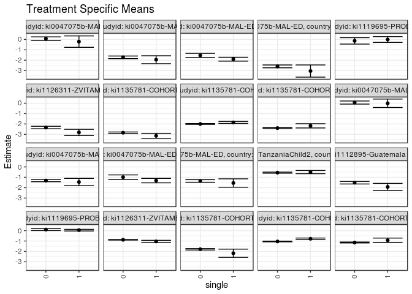

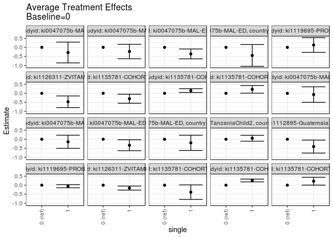

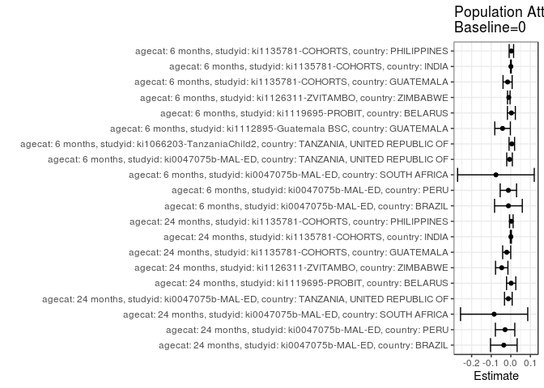

## Results Table

### Parameter: TSM

| agecat | studyid | country | intervention_level | baseline_level | estimate | ci_lower | ci_upper |
| --- | --- | --- | --- | --- | --- | --- | --- |
| 6 months | ki0047075b-MAL-ED | BRAZIL | 0 | NA | 0.0631286 | -0.0866593 | 0.2129165 |
| 6 months | ki0047075b-MAL-ED | BRAZIL | 1 | NA | -0.0077243 | -0.4129734 | 0.3975249 |
| 6 months | ki0047075b-MAL-ED | PERU | 0 | NA | -1.3143288 | -1.4279853 | -1.2006724 |
| 6 months | ki0047075b-MAL-ED | PERU | 1 | NA | -1.4552372 | -1.8035914 | -1.1068830 |
| 6 months | ki0047075b-MAL-ED | SOUTH AFRICA | 0 | NA | -0.9874117 | -1.2051968 | -0.7696266 |
| 6 months | ki0047075b-MAL-ED | SOUTH AFRICA | 1 | NA | -1.3201832 | -1.5342144 | -1.1061519 |
| 6 months | ki0047075b-MAL-ED | TANZANIA, UNITED REPUBLIC OF | 0 | NA | -1.3537169 | -1.4790610 | -1.2283727 |
| 6 months | ki0047075b-MAL-ED | TANZANIA, UNITED REPUBLIC OF | 1 | NA | -1.5514583 | -1.9539746 | -1.1489420 |
| 6 months | ki1066203-TanzaniaChild2 | TANZANIA, UNITED REPUBLIC OF | 0 | NA | -0.5509933 | -0.6023280 | -0.4996585 |
| 6 months | ki1066203-TanzaniaChild2 | TANZANIA, UNITED REPUBLIC OF | 1 | NA | -0.4971056 | -0.6519777 | -0.3422334 |
| 6 months | ki1112895-Guatemala BSC | GUATEMALA | 0 | NA | -1.5203368 | -1.6426949 | -1.3979787 |
| 6 months | ki1112895-Guatemala BSC | GUATEMALA | 1 | NA | -1.9261527 | -2.2638332 | -1.5884721 |
| 6 months | ki1119695-PROBIT | BELARUS | 0 | NA | 0.1040038 | 0.0075252 | 0.2004823 |
| 6 months | ki1119695-PROBIT | BELARUS | 1 | NA | 0.0464646 | -0.0322471 | 0.1251763 |
| 6 months | ki1126311-ZVITAMBO | ZIMBABWE | 0 | NA | -0.8802957 | -0.9069227 | -0.8536687 |
| 6 months | ki1126311-ZVITAMBO | ZIMBABWE | 1 | NA | -1.0404179 | -1.1493522 | -0.9314835 |
| 6 months | ki1135781-COHORTS | GUATEMALA | 0 | NA | -1.7925722 | -1.8658077 | -1.7193367 |
| 6 months | ki1135781-COHORTS | GUATEMALA | 1 | NA | -2.1786440 | -2.5735766 | -1.7837114 |
| 6 months | ki1135781-COHORTS | INDIA | 0 | NA | -1.0423478 | -1.0757913 | -1.0089044 |
| 6 months | ki1135781-COHORTS | INDIA | 1 | NA | -0.7833333 | -0.8545896 | -0.7120771 |
| 6 months | ki1135781-COHORTS | PHILIPPINES | 0 | NA | -1.1443910 | -1.1885939 | -1.1001880 |
| 6 months | ki1135781-COHORTS | PHILIPPINES | 1 | NA | -0.9252584 | -1.1353285 | -0.7151883 |
| 24 months | ki0047075b-MAL-ED | BRAZIL | 0 | NA | 0.0774718 | -0.0985775 | 0.2535210 |
| 24 months | ki0047075b-MAL-ED | BRAZIL | 1 | NA | -0.2072491 | -0.7566117 | 0.3421136 |
| 24 months | ki0047075b-MAL-ED | PERU | 0 | NA | -1.7209033 | -1.8468976 | -1.5949091 |
| 24 months | ki0047075b-MAL-ED | PERU | 1 | NA | -1.9501649 | -2.3319559 | -1.5683739 |
| 24 months | ki0047075b-MAL-ED | SOUTH AFRICA | 0 | NA | -1.5377160 | -1.7386744 | -1.3367575 |
| 24 months | ki0047075b-MAL-ED | SOUTH AFRICA | 1 | NA | -1.9020502 | -2.0889352 | -1.7151653 |
| 24 months | ki0047075b-MAL-ED | TANZANIA, UNITED REPUBLIC OF | 0 | NA | -2.5933173 | -2.7301853 | -2.4564493 |
| 24 months | ki0047075b-MAL-ED | TANZANIA, UNITED REPUBLIC OF | 1 | NA | -3.0416667 | -3.6297264 | -2.4536070 |
| 24 months | ki1119695-PROBIT | BELARUS | 0 | NA | -0.1333282 | -0.4427659 | 0.1761096 |
| 24 months | ki1119695-PROBIT | BELARUS | 1 | NA | -0.0040729 | -0.2850721 | 0.2769262 |
| 24 months | ki1126311-ZVITAMBO | ZIMBABWE | 0 | NA | -2.3461487 | -2.4667375 | -2.2255600 |
| 24 months | ki1126311-ZVITAMBO | ZIMBABWE | 1 | NA | -2.8139844 | -3.1128892 | -2.5150797 |
| 24 months | ki1135781-COHORTS | GUATEMALA | 0 | NA | -2.8434454 | -2.9128897 | -2.7740011 |
| 24 months | ki1135781-COHORTS | GUATEMALA | 1 | NA | -3.1442163 | -3.3849632 | -2.9034694 |
| 24 months | ki1135781-COHORTS | INDIA | 0 | NA | -2.0012143 | -2.0414003 | -1.9610283 |
| 24 months | ki1135781-COHORTS | INDIA | 1 | NA | -1.8522222 | -1.9508516 | -1.7535928 |
| 24 months | ki1135781-COHORTS | PHILIPPINES | 0 | NA | -2.3988990 | -2.4455199 | -2.3522781 |
| 24 months | ki1135781-COHORTS | PHILIPPINES | 1 | NA | -2.1814435 | -2.3844575 | -1.9784295 |

### Parameter: E(Y)

| agecat | studyid | country | intervention_level | baseline_level | estimate | ci_lower | ci_upper |
| --- | --- | --- | --- | --- | --- | --- | --- |
| 6 months | ki0047075b-MAL-ED | BRAZIL | NA | NA | 0.0510207 | -0.0930194 | 0.1950608 |
| 6 months | ki0047075b-MAL-ED | PERU | NA | NA | -1.3268010 | -1.4351217 | -1.2184802 |
| 6 months | ki0047075b-MAL-ED | SOUTH AFRICA | NA | NA | -1.0633760 | -1.1911088 | -0.9356432 |
| 6 months | ki0047075b-MAL-ED | TANZANIA, UNITED REPUBLIC OF | NA | NA | -1.3601215 | -1.4821830 | -1.2380600 |
| 6 months | ki1066203-TanzaniaChild2 | TANZANIA, UNITED REPUBLIC OF | NA | NA | -0.5457721 | -0.5948454 | -0.4966988 |
| 6 months | ki1112895-Guatemala BSC | GUATEMALA | NA | NA | -1.5624368 | -1.6783540 | -1.4465196 |
| 6 months | ki1119695-PROBIT | BELARUS | NA | NA | 0.1069986 | 0.0122286 | 0.2017686 |
| 6 months | ki1126311-ZVITAMBO | ZIMBABWE | NA | NA | -0.8906213 | -0.9166407 | -0.8646018 |
| 6 months | ki1135781-COHORTS | GUATEMALA | NA | NA | -1.8089474 | -1.8800645 | -1.7378303 |
| 6 months | ki1135781-COHORTS | INDIA | NA | NA | -1.0418789 | -1.0745363 | -1.0092215 |
| 6 months | ki1135781-COHORTS | PHILIPPINES | NA | NA | -1.1414425 | -1.1836656 | -1.0992193 |
| 24 months | ki0047075b-MAL-ED | BRAZIL | NA | NA | 0.0418343 | -0.1253834 | 0.2090521 |
| 24 months | ki0047075b-MAL-ED | PERU | NA | NA | -1.7500995 | -1.8705474 | -1.6296516 |
| 24 months | ki0047075b-MAL-ED | SOUTH AFRICA | NA | NA | -1.6228361 | -1.7581177 | -1.4875546 |
| 24 months | ki0047075b-MAL-ED | TANZANIA, UNITED REPUBLIC OF | NA | NA | -2.6058879 | -2.7403043 | -2.4714714 |
| 24 months | ki1119695-PROBIT | BELARUS | NA | NA | -0.1314048 | -0.4282725 | 0.1654630 |
| 24 months | ki1126311-ZVITAMBO | ZIMBABWE | NA | NA | -2.3925000 | -2.5069364 | -2.2780636 |
| 24 months | ki1135781-COHORTS | GUATEMALA | NA | NA | -2.8644028 | -2.9307312 | -2.7980743 |
| 24 months | ki1135781-COHORTS | INDIA | NA | NA | -2.0008573 | -2.0401168 | -1.9615978 |
| 24 months | ki1135781-COHORTS | PHILIPPINES | NA | NA | -2.3962210 | -2.4413335 | -2.3511085 |

### Parameter: ATE

| agecat | studyid | country | intervention_level | baseline_level | estimate | ci_lower | ci_upper |
| --- | --- | --- | --- | --- | --- | --- | --- |
| 6 months | ki0047075b-MAL-ED | BRAZIL | 0 | 0 | 0.0000000 | 0.0000000 | 0.0000000 |
| 6 months | ki0047075b-MAL-ED | BRAZIL | 1 | 0 | -0.0708529 | -0.5021199 | 0.3604142 |
| 6 months | ki0047075b-MAL-ED | PERU | 0 | 0 | 0.0000000 | 0.0000000 | 0.0000000 |
| 6 months | ki0047075b-MAL-ED | PERU | 1 | 0 | -0.1409084 | -0.5042890 | 0.2224723 |
| 6 months | ki0047075b-MAL-ED | SOUTH AFRICA | 0 | 0 | 0.0000000 | 0.0000000 | 0.0000000 |
| 6 months | ki0047075b-MAL-ED | SOUTH AFRICA | 1 | 0 | -0.3327715 | -0.6362735 | -0.0292694 |
| 6 months | ki0047075b-MAL-ED | TANZANIA, UNITED REPUBLIC OF | 0 | 0 | 0.0000000 | 0.0000000 | 0.0000000 |
| 6 months | ki0047075b-MAL-ED | TANZANIA, UNITED REPUBLIC OF | 1 | 0 | -0.1977415 | -0.6193224 | 0.2238395 |
| 6 months | ki1066203-TanzaniaChild2 | TANZANIA, UNITED REPUBLIC OF | 0 | 0 | 0.0000000 | 0.0000000 | 0.0000000 |
| 6 months | ki1066203-TanzaniaChild2 | TANZANIA, UNITED REPUBLIC OF | 1 | 0 | 0.0538877 | -0.1084195 | 0.2161949 |
| 6 months | ki1112895-Guatemala BSC | GUATEMALA | 0 | 0 | 0.0000000 | 0.0000000 | 0.0000000 |
| 6 months | ki1112895-Guatemala BSC | GUATEMALA | 1 | 0 | -0.4058158 | -0.7649286 | -0.0467030 |
| 6 months | ki1119695-PROBIT | BELARUS | 0 | 0 | 0.0000000 | 0.0000000 | 0.0000000 |
| 6 months | ki1119695-PROBIT | BELARUS | 1 | 0 | -0.0575391 | -0.1460764 | 0.0309982 |
| 6 months | ki1126311-ZVITAMBO | ZIMBABWE | 0 | 0 | 0.0000000 | 0.0000000 | 0.0000000 |
| 6 months | ki1126311-ZVITAMBO | ZIMBABWE | 1 | 0 | -0.1601222 | -0.2710515 | -0.0491929 |
| 6 months | ki1135781-COHORTS | GUATEMALA | 0 | 0 | 0.0000000 | 0.0000000 | 0.0000000 |
| 6 months | ki1135781-COHORTS | GUATEMALA | 1 | 0 | -0.3860718 | -0.7880982 | 0.0159546 |
| 6 months | ki1135781-COHORTS | INDIA | 0 | 0 | 0.0000000 | 0.0000000 | 0.0000000 |
| 6 months | ki1135781-COHORTS | INDIA | 1 | 0 | 0.2590145 | 0.1803003 | 0.3377287 |
| 6 months | ki1135781-COHORTS | PHILIPPINES | 0 | 0 | 0.0000000 | 0.0000000 | 0.0000000 |
| 6 months | ki1135781-COHORTS | PHILIPPINES | 1 | 0 | 0.2191326 | 0.0044685 | 0.4337967 |
| 24 months | ki0047075b-MAL-ED | BRAZIL | 0 | 0 | 0.0000000 | 0.0000000 | 0.0000000 |
| 24 months | ki0047075b-MAL-ED | BRAZIL | 1 | 0 | -0.2847208 | -0.8598123 | 0.2903706 |
| 24 months | ki0047075b-MAL-ED | PERU | 0 | 0 | 0.0000000 | 0.0000000 | 0.0000000 |
| 24 months | ki0047075b-MAL-ED | PERU | 1 | 0 | -0.2292616 | -0.6291053 | 0.1705822 |
| 24 months | ki0047075b-MAL-ED | SOUTH AFRICA | 0 | 0 | 0.0000000 | 0.0000000 | 0.0000000 |
| 24 months | ki0047075b-MAL-ED | SOUTH AFRICA | 1 | 0 | -0.3643343 | -0.6375568 | -0.0911117 |
| 24 months | ki0047075b-MAL-ED | TANZANIA, UNITED REPUBLIC OF | 0 | 0 | 0.0000000 | 0.0000000 | 0.0000000 |
| 24 months | ki0047075b-MAL-ED | TANZANIA, UNITED REPUBLIC OF | 1 | 0 | -0.4483494 | -1.0521267 | 0.1554280 |
| 24 months | ki1119695-PROBIT | BELARUS | 0 | 0 | 0.0000000 | 0.0000000 | 0.0000000 |
| 24 months | ki1119695-PROBIT | BELARUS | 1 | 0 | 0.1292552 | -0.2796633 | 0.5381737 |
| 24 months | ki1126311-ZVITAMBO | ZIMBABWE | 0 | 0 | 0.0000000 | 0.0000000 | 0.0000000 |
| 24 months | ki1126311-ZVITAMBO | ZIMBABWE | 1 | 0 | -0.4678357 | -0.7880613 | -0.1476101 |
| 24 months | ki1135781-COHORTS | GUATEMALA | 0 | 0 | 0.0000000 | 0.0000000 | 0.0000000 |
| 24 months | ki1135781-COHORTS | GUATEMALA | 1 | 0 | -0.3007709 | -0.5510585 | -0.0504834 |
| 24 months | ki1135781-COHORTS | INDIA | 0 | 0 | 0.0000000 | 0.0000000 | 0.0000000 |
| 24 months | ki1135781-COHORTS | INDIA | 1 | 0 | 0.1489921 | 0.0424901 | 0.2554941 |
| 24 months | ki1135781-COHORTS | PHILIPPINES | 0 | 0 | 0.0000000 | 0.0000000 | 0.0000000 |
| 24 months | ki1135781-COHORTS | PHILIPPINES | 1 | 0 | 0.2174555 | 0.0091784 | 0.4257326 |

### Parameter: PAR

| agecat | studyid | country | intervention_level | baseline_level | estimate | ci_lower | ci_upper |
| --- | --- | --- | --- | --- | --- | --- | --- |
| 6 months | ki0047075b-MAL-ED | BRAZIL | 0 | NA | -0.0121079 | -0.0829022 | 0.0586864 |
| 6 months | ki0047075b-MAL-ED | PERU | 0 | NA | -0.0124721 | -0.0542605 | 0.0293163 |
| 6 months | ki0047075b-MAL-ED | SOUTH AFRICA | 0 | NA | -0.0759643 | -0.2716679 | 0.1197393 |
| 6 months | ki0047075b-MAL-ED | TANZANIA, UNITED REPUBLIC OF | 0 | NA | -0.0064046 | -0.0207426 | 0.0079335 |
| 6 months | ki1066203-TanzaniaChild2 | TANZANIA, UNITED REPUBLIC OF | 0 | NA | 0.0052212 | -0.0088605 | 0.0193029 |
| 6 months | ki1112895-Guatemala BSC | GUATEMALA | 0 | NA | -0.0421000 | -0.0819136 | -0.0022864 |
| 6 months | ki1119695-PROBIT | BELARUS | 0 | NA | 0.0029949 | -0.0171894 | 0.0231792 |
| 6 months | ki1126311-ZVITAMBO | ZIMBABWE | 0 | NA | -0.0103256 | -0.0167555 | -0.0038957 |
| 6 months | ki1135781-COHORTS | GUATEMALA | 0 | NA | -0.0163751 | -0.0397084 | 0.0069581 |
| 6 months | ki1135781-COHORTS | INDIA | 0 | NA | 0.0004689 | -0.0015226 | 0.0024605 |
| 6 months | ki1135781-COHORTS | PHILIPPINES | 0 | NA | 0.0029485 | -0.0084000 | 0.0142970 |
| 24 months | ki0047075b-MAL-ED | BRAZIL | 0 | NA | -0.0356375 | -0.1035910 | 0.0323161 |
| 24 months | ki0047075b-MAL-ED | PERU | 0 | NA | -0.0291962 | -0.0787411 | 0.0203488 |
| 24 months | ki0047075b-MAL-ED | SOUTH AFRICA | 0 | NA | -0.0851202 | -0.2567303 | 0.0864899 |
| 24 months | ki0047075b-MAL-ED | TANZANIA, UNITED REPUBLIC OF | 0 | NA | -0.0125705 | -0.0322012 | 0.0070601 |
| 24 months | ki1119695-PROBIT | BELARUS | 0 | NA | 0.0019234 | -0.0216636 | 0.0255103 |
| 24 months | ki1126311-ZVITAMBO | ZIMBABWE | 0 | NA | -0.0463513 | -0.0779775 | -0.0147251 |
| 24 months | ki1135781-COHORTS | GUATEMALA | 0 | NA | -0.0209574 | -0.0414585 | -0.0004562 |
| 24 months | ki1135781-COHORTS | INDIA | 0 | NA | 0.0003570 | -0.0023157 | 0.0030297 |
| 24 months | ki1135781-COHORTS | PHILIPPINES | 0 | NA | 0.0026780 | -0.0064611 | 0.0118171 |